# Regression Models: Mtcars

Ariel Lev

May 2015

### Executive Summary

With a confidence level of 95%, vehicles equiped with manual transmission drive between 0.05 to 5.83 more miles per gallon than vehicle equiped with automatic transmission.

### Exploratory data analysis

The data, extracted from 1974 Motor Trend magazine, comprise gasoline mileage in miles per gallon (MPG), and 10 aspects of automotive design and performance for 32 vehicles. The regression model attemps to quantify the MPG difference between automatic and manual transmissions.

Table 1.|Data for Motor Trend sample of 32 automobiles

|  | mpg | cyl | disp | hp | drat | wt | qsec | vs | am | gear | carb |
| --- | --- | --- | --- | --- | --- | --- | --- | --- | --- | --- | --- |
| Mazda RX4 | 21.0 | 6 | 160 | 110 | 3.90 | 2.620 | 16.46 | 0 | 1 | 4 | 4 |
| Mazda RX4 Wag | 21.0 | 6 | 160 | 110 | 3.90 | 2.875 | 17.02 | 0 | 1 | 4 | 4 |
| Datsun 710 | 22.8 | 4 | 108 | 93 | 3.85 | 2.320 | 18.61 | 1 | 1 | 4 | 1 |
| Hornet 4 Drive | 21.4 | 6 | 258 | 110 | 3.08 | 3.215 | 19.44 | 1 | 0 | 3 | 1 |
| Hornet Sportabout | 18.7 | 8 | 360 | 175 | 3.15 | 3.440 | 17.02 | 0 | 0 | 3 | 2 |

### Regression Anaylsis

In order to study the change in the response variable MPG regarding the transmission type, any linear model must take AM as a term.

```r
fit0 <- lm(mpg ~ factor(am), data = mtcars)
summary(fit0)$r.squared
```

```
## [1] 0.3597989
```

However AM can be accounted only for a little of the variance of MPG. Our basic model reports a R square of only 35.98%. In addition, checking the parital correlation of MPG and AM, controlled by WT, we can see that there is hardly **any** correlation between the two.

```r
pcor(c("mpg", "am", "wt"), var(mtcars))
```

```
## [1] -0.002837144
```

Correlation of MPG against each one of the features suggests WT as the best single predictor. There is a loose physicall argument that supports this model, as distance can be considered as work applied to a vehicle’s body. The following code shows the 7 most with MPG correlated features, given in absoulte values, sorted from biggest to smallest. A complete correlation matrix is depcit by Figure 1.

```r
sort(abs(cor(mtcars)[1, -c(1)]), decreasing = T)[1:7]
```

```
##        wt       cyl      disp        hp      drat        vs        am
## 0.8676594 0.8521620 0.8475514 0.7761684 0.6811719 0.6640389 0.5998324
```

```r
# shifting wt by its mean in order to yield meaningfull intercept values
fit1 <- update(fit0, . ~ . + I(wt - mean(wt)), data = mtcars)
summary(fit1)$r.squared
```

```
## [1] 0.7528348
```

After adding WT as a term we not only get a far larger R square, but a variance analysis yields a 46.12 F-Ratio with a very small p-value suggesting a real improvement to the predcition force of our model.

```r
anv <- anova(fit0,fit1)
data.frame( F = anv$"F"[2], "p-value" = anv$"Pr(>F)"[2])
```

```
##          F      p.value
## 1 46.11506 1.867415e-07
```

Predciting MPG performance may be subtle to inaccuracy, when excluding (at least intutively) an important aspect such as engine fuel consumption. When adding a third regressor to the model, i was considering either engine displacment ( a general indicator of its size and power) or 1/4 mile time. By repating the above procedure I found out that 1/4 mile time is a slightly better contributer than displacement. By adding a forth regressor, the procedure looses its strength, and it is hard to improve the model any further.

```r
# shifting qsec by its mean in order to yield meaningfull intercept values
fit2 <- update(fit1, . ~ . + I(qsec - mean(qsec)), data = mtcars)
summary(fit2)
```

```
##
## Call:
## lm(formula = mpg ~ factor(am) + I(wt - mean(wt)) + I(qsec - mean(qsec)),
##     data = mtcars)
##
## Residuals:
##     Min      1Q  Median      3Q     Max
## -3.4811 -1.5555 -0.7257  1.4110  4.6610
##
## Coefficients:
##                      Estimate Std. Error t value Pr(>|t|)
## (Intercept)           18.8979     0.7194  26.271  < 2e-16 ***
## factor(am)1            2.9358     1.4109   2.081 0.046716 *
## I(wt - mean(wt))      -3.9165     0.7112  -5.507 6.95e-06 ***
## I(qsec - mean(qsec))   1.2259     0.2887   4.247 0.000216 ***
## ---
## Signif. codes:  0 '***' 0.001 '**' 0.01 '*' 0.05 '.' 0.1 ' ' 1
##
## Residual standard error: 2.459 on 28 degrees of freedom
## Multiple R-squared:  0.8497, Adjusted R-squared:  0.8336
## F-statistic: 52.75 on 3 and 28 DF,  p-value: 1.21e-11
```

```r
# extracting confidence intervals
sumCoef <- summary(fit2)$coefficients
conf1 <- sumCoef[1, ] + c(-1, 1) * qt(0.975, fit2$df) * sumCoef[, 2]
ci <- data.frame(low = c(), high = c())
for (i in 1:4) {
    ci <- rbind(ci, round(c(sumCoef[i, 1], sumCoef[i, 1] + c(-1, 1) * qt(0.975,
        fit2$df) * sumCoef[i, 2]), 2))
}
names(ci) <- c("coeff", "low", "high")
row.names(ci) <- row.names(sumCoef)
ci
```

```
##                      coeff   low  high
## (Intercept)          18.90 17.42 20.37
## factor(am)1           2.94  0.05  5.83
## I(wt - mean(wt))     -3.92 -5.37 -2.46
## I(qsec - mean(qsec))  1.23  0.63  1.82
```

# Appendix

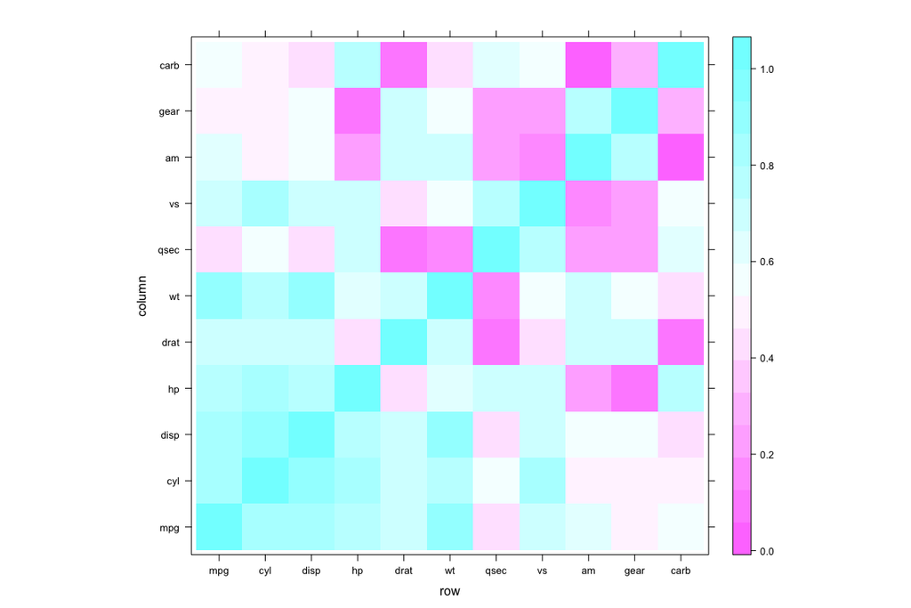

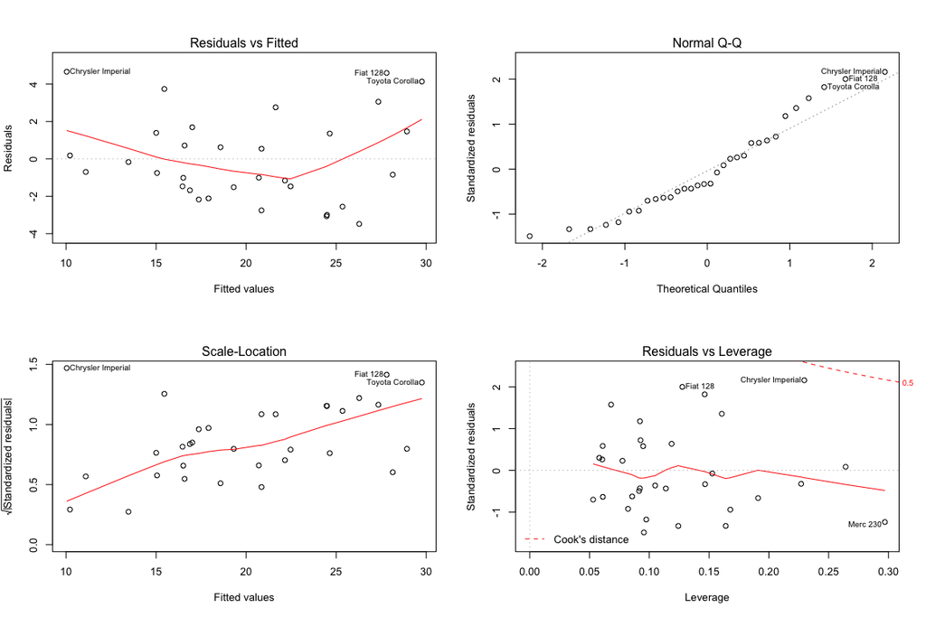